# Part I - Ford GoBike System Data

## Preliminary Wrangling

```python
# import all packages and set plots to be embedded inline
import numpy as np
import pandas as pd
import matplotlib.pyplot as plt
import seaborn as sb

%matplotlib inline
```

> Load in your dataset and describe its properties through the questions below. Try and motivate your exploration goals through this section.

```python
# load in the dataset into a pandas dataframe, print statistics
df=pd.read_csv('201902-fordgobike-tripdata.csv')
```

```python
# high-level overview of data shape and composition
print(df.shape)
print(df.dtypes)
print(df.head(10))
```

```
(183412, 16)
duration_sec                 int64
start_time                  object
end_time                    object
start_station_id           float64
start_station_name          object
start_station_latitude     float64
start_station_longitude    float64
end_station_id             float64
end_station_name            object
end_station_latitude       float64
end_station_longitude      float64
bike_id                      int64
user_type                   object
member_birth_year          float64
member_gender               object
bike_share_for_all_trip     object
dtype: object
   duration_sec                start_time                  end_time  \
0         52185  2019-02-28 17:32:10.1450  2019-03-01 08:01:55.9750
1         42521  2019-02-28 18:53:21.7890  2019-03-01 06:42:03.0560
2         61854  2019-02-28 12:13:13.2180  2019-03-01 05:24:08.1460
3         36490  2019-02-28 17:54:26.0100  2019-03-01 04:02:36.8420
4          1585  2019-02-28 23:54:18.5490  2019-03-01 00:20:44.0740
5          1793  2019-02-28 23:49:58.6320  2019-03-01 00:19:51.7600
6          1147  2019-02-28 23:55:35.1040  2019-03-01 00:14:42.5880
7          1615  2019-02-28 23:41:06.7660  2019-03-01 00:08:02.7560
8          1570  2019-02-28 23:41:48.7900  2019-03-01 00:07:59.7150
9          1049  2019-02-28 23:49:47.6990  2019-03-01 00:07:17.0250

   start_station_id                                start_station_name  \
0              21.0  Montgomery St BART Station (Market St at 2nd St)
1              23.0                     The Embarcadero at Steuart St
2              86.0                           Market St at Dolores St
3             375.0                           Grove St at Masonic Ave
4               7.0                               Frank H Ogawa Plaza
5              93.0                      4th St at Mission Bay Blvd S
6             300.0                              Palm St at Willow St
7              10.0                        Washington St at Kearny St
8              10.0                        Washington St at Kearny St
```

[output cut: 34 more lines]

```
7            -122.421025     6329  Subscriber             1989.0
8            -122.421025     6548  Subscriber             1988.0
9            -122.421339     6488  Subscriber             1992.0

  member_gender bike_share_for_all_trip
0          Male                      No
1           NaN                      No
2          Male                      No
3         Other                      No
4          Male                     Yes
5          Male                      No
6        Female                      No
7          Male                      No
8         Other                      No
9          Male                      No
```

```python
# descriptive statistics for numeric variables
df.describe()
```

|  | duration_sec | start_station_id | start_station_latitude | start_station_longitude | end_station_id | end_station_latitude | end_station_longitude | bike_id | member_birth_year |
| --- | --- | --- | --- | --- | --- | --- | --- | --- | --- |
| count | 183412.000000 | 183215.000000 | 183412.000000 | 183412.000000 | 183215.000000 | 183412.000000 | 183412.000000 | 183412.000000 | 175147.000000 |
| mean | 726.078435 | 138.590427 | 37.771223 | -122.352664 | 136.249123 | 37.771427 | -122.352250 | 4472.906375 | 1984.806437 |
| std | 1794.389780 | 111.778864 | 0.099581 | 0.117097 | 111.515131 | 0.099490 | 0.116673 | 1664.383394 | 10.116689 |
| min | 61.000000 | 3.000000 | 37.317298 | -122.453704 | 3.000000 | 37.317298 | -122.453704 | 11.000000 | 1878.000000 |
| 25% | 325.000000 | 47.000000 | 37.770083 | -122.412408 | 44.000000 | 37.770407 | -122.411726 | 3777.000000 | 1980.000000 |
| 50% | 514.000000 | 104.000000 | 37.780760 | -122.398285 | 100.000000 | 37.781010 | -122.398279 | 4958.000000 | 1987.000000 |
| 75% | 796.000000 | 239.000000 | 37.797280 | -122.286533 | 235.000000 | 37.797320 | -122.288045 | 5502.000000 | 1992.000000 |
| max | 85444.000000 | 398.000000 | 37.880222 | -121.874119 | 398.000000 | 37.880222 | -121.874119 | 6645.000000 | 2001.000000 |

```python
# check datatype of start_time
type(df.start_time[0])
```

```
str
```

### What is the structure of your dataset?

bike_share_for_all_trip: Yes, NO  
member_gender: Male, Female, Other  
user_type: Customer, Subscriber

### What is/are the main feature(s) of interest in your dataset?

My interest in on finding out the factors that will best predict a trips' durations

### What features in the dataset do you think will help support your investigation into your feature(s) of interest?

User type is going to have the highest influence on duration: Customers pay for the duration spent on the bike while subscribers pay for the sevice for a durtion usually monthly. gender and bike_share_for_all_trip will also be investigated

## Univariate Exploration

I will begin with a distribution plot of duration

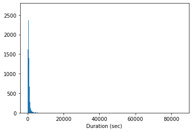

```python
# start with a standard-scaled plot
binsize = 10
bins = np.arange(0, df['duration_sec'].max()+binsize, binsize)
# plt.figure(figsize=[8, 5])
plt.hist(data = df, x = 'duration_sec', bins = bins)
plt.xlabel('Duration (sec)')
plt.show()
```

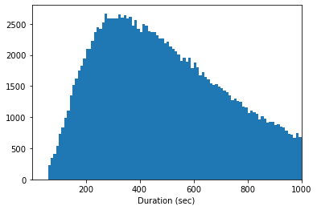

```python
# zoom into the tailed area
plt.hist(data = df, x = 'duration_sec', bins = bins)
plt.xlabel('Duration (sec)')
plt.xlim([0.1,1000])
plt.show()
```

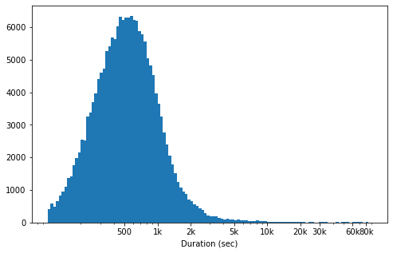

```python
# there's a long tail in the distribution and plot concerntrated in a small portion, so let's put it on a log scale instead
log_binsize = 0.025
bins = 10 ** np.arange(2.0, np.log10(df['duration_sec'].max())+log_binsize, log_binsize)

plt.figure(figsize=[8, 5])
plt.hist(data = df, x = 'duration_sec', bins = bins)
plt.xscale('log')
plt.xticks([500, 1e3, 2e3, 5e3, 1e4, 2e4, 3e4,6e4,8e4], [500, '1k', '2k', '5k', '10k', '20k','30k','60k','80k'])
# plt.xlim([100,])
plt.xlabel('Duration (sec)')
plt.show()
```

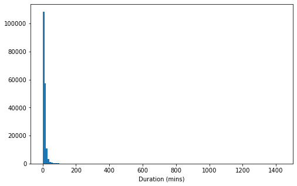

```python
# the plot isn't the best as less entail can be depicted convert duration in seconds to minutes
df['duration_min']=df['duration_sec'].apply(lambda x:x/60)
binsize = 10
bins = np.arange(0, df['duration_min'].max()+binsize, binsize)

plt.figure(figsize=[8, 5])
plt.hist(data = df, x = 'duration_min', bins = bins)
plt.xlabel('Duration (mins)')
plt.show()
```

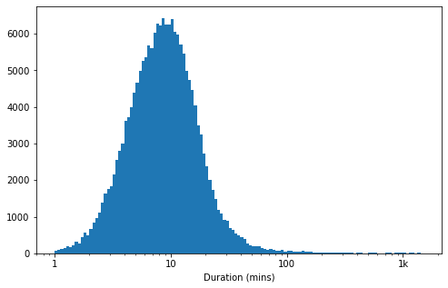

```python
# there's a long tail in the distribution and plot concerntrated in a small portion, so let's put it on a log scale instead
log_binsize = 0.025
bins = 10 ** np.arange(0.0, np.log10(df['duration_min'].max())+log_binsize, log_binsize)

plt.figure(figsize=[8, 5])
plt.hist(data = df, x = 'duration_min', bins = bins)
plt.xscale('log')
plt.xticks([1, 10, 1e2,1e3], [1,10,100, '1k'])
plt.xlabel('Duration (mins)')
plt.show()
```

Duration has a long-tailed distribution, with a lot of trips on the short duration end, and few on the long duration end. When plotted on a log-scale, the duration distribution has a doom shape, with a peak between 500 and 1000 seconds. A plot of the duration in minutes gives the same tail and doom shape as with duration in seconds

Next up, the first predictor variable of interest: start_day.

```python
# convert start_time to a datatime datatype
df.start_time=pd.to_datetime(df.start_time)
```

```python
# create and column for start_day of trip and fill it with day extracted from start_time
df['start_day']=df.start_time.dt.day
```

```python
default_color = sb.color_palette()[0]
```

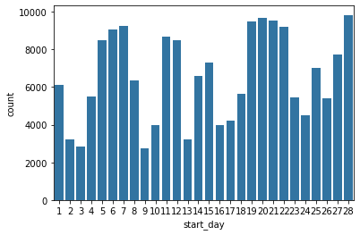

```python
# plot of trip distribution across all days in febuary
sb.countplot(data=df, x='start_day',color=default_color);
```

trip distribution accross all days indicate that day 28 had the highest number of trips followed by day 20 with day 3 and 9 having the least number of trips

I will now continue with member_gender, user_type and bike_share_for_all_trip

```python
# function to do a countplot
def do_countplot(column):
    sb.countplot(data = df, x = column, color = default_color)
    plt.show()
```

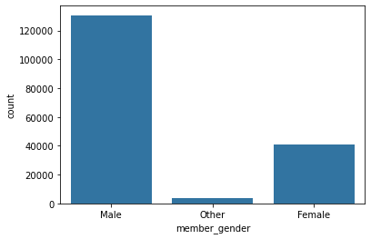

```python
# distribution of gender
do_countplot('member_gender')
```

This bar chart indicates that males take the highest number of trips with bikes followed by females and then other gender

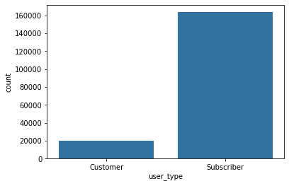

```python
# user_type distribution
do_countplot('user_type')
```

Majority of the trips are taken by subscribers as compared to customers

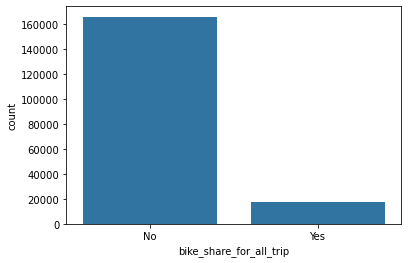

```python
# bike share for all trip plot
do_countplot('bike_share_for_all_trip')
```

Most of the trips have been by those who don't take bike share for all their trips

Verifying member birth year variable in the dataset

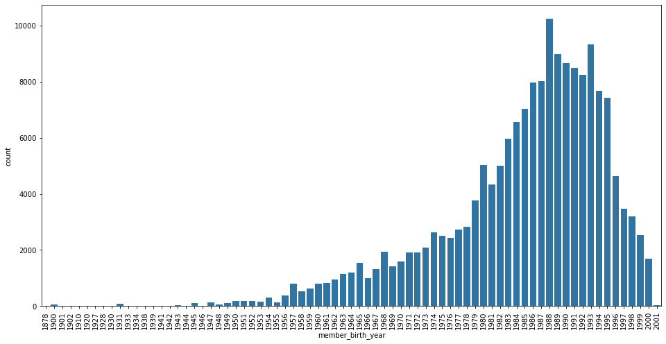

```python
# plot of member-birth_year
sub=df[df.member_birth_year.notna()]
sub['member_birth_year']=sub.member_birth_year.apply(np.int64)
plt.figure(figsize=(16,8))
plt.xticks(rotation=90)
sb.countplot(data = sub, x = 'member_birth_year', color = default_color);
```

a count plot of member birth year indicates a continual increase in the number of trips for members of each year up 1989 with a peak maximum for member of birth year 1988 and and rapid drop from 1995 right down to 2001

### Discuss the distribution(s) of your variable(s) of interest. Were there any unusual points? Did you need to perform any transformations?

The duration variable took on a large range of values, so I looked at the data using a log transform. Under the transformation, the data plot had a doom shape, with a maximum peak between 500𝑎𝑛𝑑 1000 seconds.

### Of the features you investigated, were there any unusual distributions? Did you perform any operations on the data to tidy, adjust, or change the form of the data? If so, why did you do this?

No unsuall distributions. I had to get the trip start day from the start time colum and had to convert the column datatype from string to a timestamp so as to be able to do so

## Bivariate Exploration

I'll start with a plot of user and start day

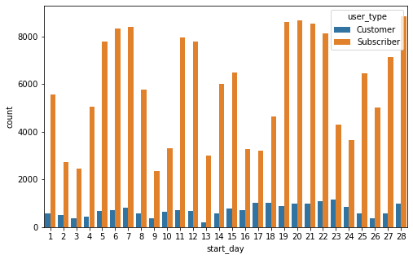

```python
#bivarate plot of day and user type
plt.figure(figsize=(8,5))
sb.countplot(data = df, x = 'start_day', hue = 'user_type');
```

this plot shows that generally most trips are performed by subscribers than customers irrespective of the day

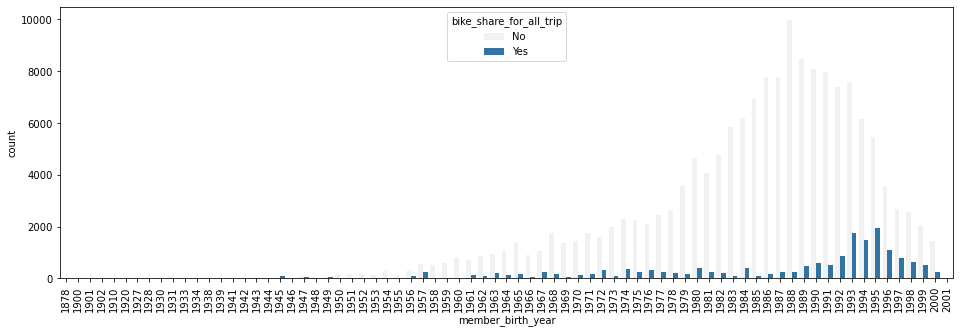

```python
# plot of year and bike share for all trips
plt.figure(figsize=(16,5))
plt.xticks(rotation=90)
sb.countplot(data = sub, x = 'member_birth_year', hue='bike_share_for_all_trip',color = default_color);
```

the number of tips made by users of eac who don't use bike share for all trip vary linearly with the count of trips of users with that same birth year

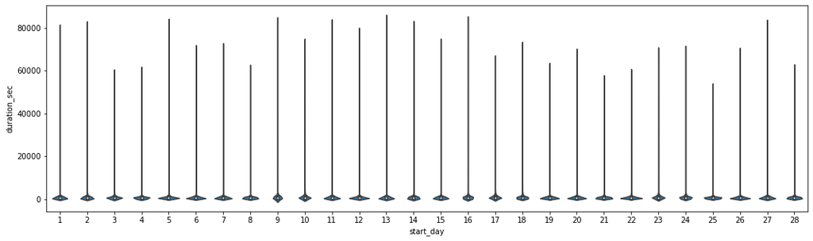

```python
# bivarate plot of  duration vs start day
plt.figure(figsize=[18,5])
sb.violinplot(data=df, x='start_day', y='duration_sec',color=default_color);
# plt.ylim([-1,30])
```

the box plot depicts only varying peak values for duration during each day a greater portion of the information is condensed in the lower part of the plot

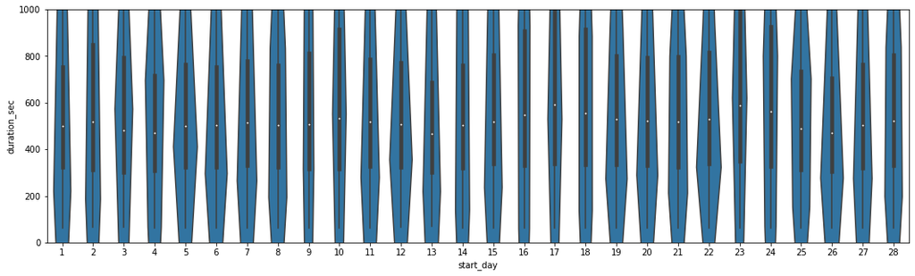

```python
# zoom into the bivarate plot of  duration vs start day
plt.figure(figsize=[18,5])
sb.violinplot(data=df, x='start_day', y='duration_sec',color=default_color);
plt.ylim(0,1000);
```

the median duration for trips in each day appear to all be betwween 450 and 550 seconds except for day 17 and 23 with a median duration of about 600 seconds

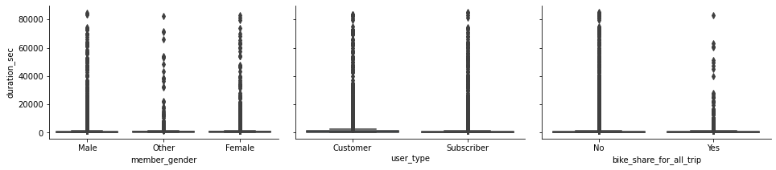

```python
# plot matrix of duration against categorical features.

def boxgrid(x, y, **kwargs):
    """ Quick hack for creating box plots with seaborn's PairGrid. """
    sb.boxplot(x, y, color = default_color);

plt.figure(figsize = [10, 10])
g = sb.PairGrid(data = df, y_vars = ['duration_sec'], x_vars = ['member_gender', 'user_type', 'bike_share_for_all_trip'],
                size = 3, aspect = 1.5,)
g.map(boxgrid)
plt.show();
```

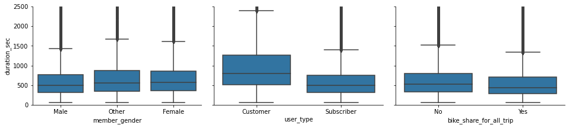

```python
# zoom into the box plots above
plt.figure(figsize = [10, 10])
g = sb.PairGrid(data = df, y_vars = ['duration_sec'], x_vars = ['member_gender', 'user_type', 'bike_share_for_all_trip'],
                size = 3, aspect = 1.5,)
g.map(boxgrid)
plt.ylim(0,2500)
plt.show();
```

the box plots indicate that gender gender alone does not influence duration that much as the median value and quartiles are almost the same difference. On the other hand the user type seem to play a significant influence with a larger number of customers in the upper quartile range with high durations. we will letter plot this on a violin plot

```python
# function to do count plot for variables member-gender , user_type and  bike share for all trip vs one other categorical variable
def do_countplot(x, y):
    plt.figure(figsize = [12, 5])
    sb.countplot(data = df, hue = y, x = x);
    plt.show();
```

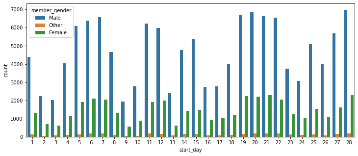

```python
# start day  vs member gender
do_countplot('start_day', 'member_gender');
```

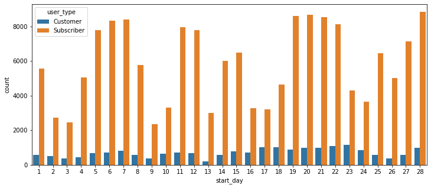

```python
# start day vs user type
do_countplot('start_day', 'user_type');
```

subscribers take the most trips

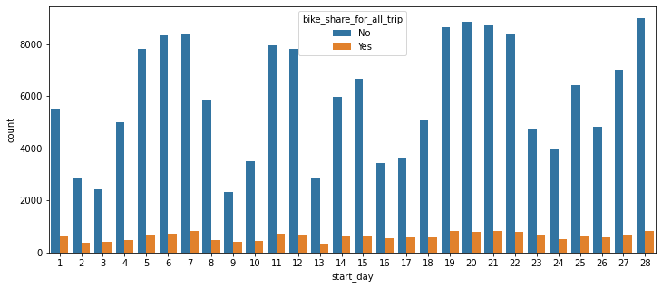

```python
# start day vs bike share for all trip
do_countplot('start_day', 'bike_share_for_all_trip');
```

most trips are taken by those who don't take bike share for all trips during all days

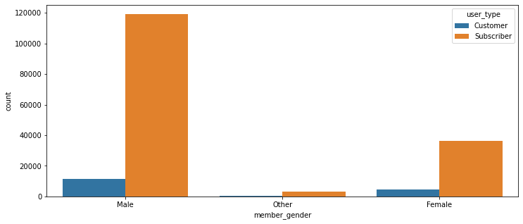

```python
# member gender and user type
do_countplot('member_gender','user_type');
```

the number of subscribers for each gender category far outnumber the number of customers

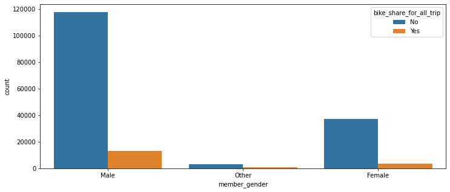

```python
# member gender vs bike_share_for_all_trip
do_countplot( 'member_gender','bike_share_for_all_trip');
```

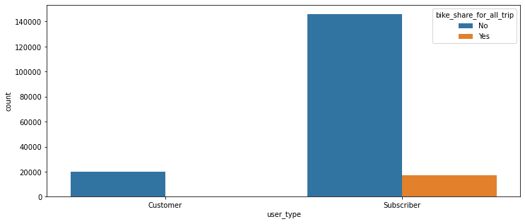

```python
# user_type vsbike_share_for_all_trip
do_countplot( 'user_type','bike_share_for_all_trip');
```

a greater number of all categories of users do not take bike_share for all trips

```python
# function to do voilin plots
def violin_plot(x,y, **kwargs):
    sb.violinplot(x, y, color = default_color);
```

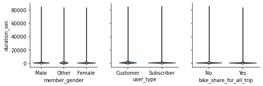

```python
plt.figure(figsize = [10, 10])
g = sb.PairGrid(data = df,y_vars=['duration_sec'], x_vars = ['member_gender', 'user_type', 'bike_share_for_all_trip'])
g.map(violin_plot)
plt.show();
```

should be better viewed on a log scale

```python
# function to do voilin plots
def violin_plot2(x,y, **kwargs):
    plt.yscale('log')
    plt.yticks([1e3,1e4,1e5],['1k','10k', '100k'])
    sb.violinplot(x, y, color = default_color,inner='quartile');
```

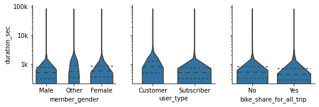

```python
# plot duration vs user_type, member_gender and bike_share_for_all_trip
plt.figure(figsize = (15, 10))
g = sb.PairGrid(data = df,y_vars=['duration_sec'], x_vars = ['member_gender', 'user_type', 'bike_share_for_all_trip'])
g.map(violin_plot2)
plt.show();
```

depicts same information as with boxplot above

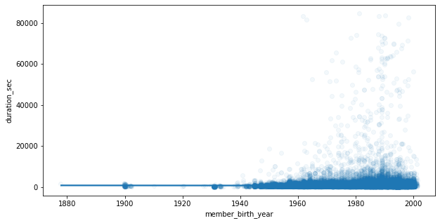

```python
# duration vs member_birth_year
plt.figure(figsize = [10, 5])
sb.regplot(data = df, x = 'member_birth_year', y = 'duration_sec',  x_jitter=0.3,scatter_kws={'alpha':1/20});
```

the plot above show must trip durations are concerntrated in the low duration part of the plot that is bellow 20000 with a few trips with higher durations above 40000

```
(1940.0, 2007.4659139402386)
```

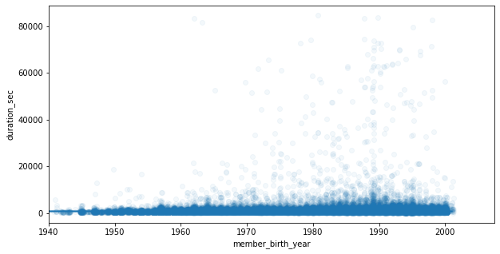

```python
# truncate impossible birthyear data
plt.figure(figsize = [10, 5])
sb.regplot(data = df, x = 'member_birth_year', y = 'duration_sec',  x_jitter=0.3,scatter_kws={'alpha':1/20});
plt.xlim(1940)
```

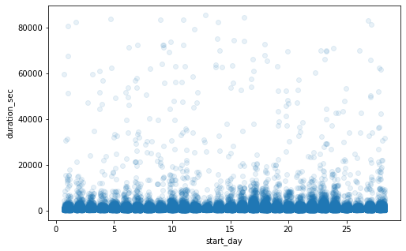

```python
plt.figure(figsize=(8,5))
sb.regplot(data = df, x = 'start_day', y = 'duration_sec',  x_jitter=0.3,scatter_kws={'alpha':1/10});
```

the plot above show must trip durations are concerntrated in the low duration part of the plot that are bellow 20000 with a few trips with higher durations above 40000 further multivariate plot will indicate which category are those

### Talk about some of the relationships you observed in this part of the investigation. How did the feature(s) of interest vary with other features in the dataset?

The duration plot vs each of member_gender, user-type and bike share for all trip showed that user_type was a huge factor in determining the duration of a trip than the other time except if combined as will be investigated further bellow to iron out this differences

### Did you observe any interesting relationships between the other features (not the main feature(s) of interest)?

When i ploted the member_birth_year and duration the plot indicated some information about users born in 1800 to even 1900 which is practcally very difficult to happen

## Multivariate Exploration

I'll be investigating how member_gender, user_type , bike_share_for_all_trip vary with duration

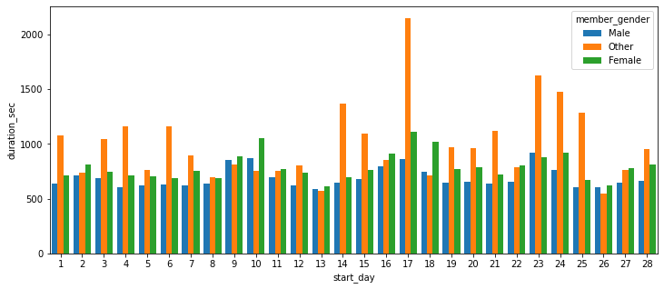

```python
# plot start day member_gender and duration
plt.figure(figsize=(12,5))
sb.barplot(x="start_day", y="duration_sec", hue="member_gender",
                data=df, ci=None,saturation=1)
plt.figure(figsize=(12,5));
```

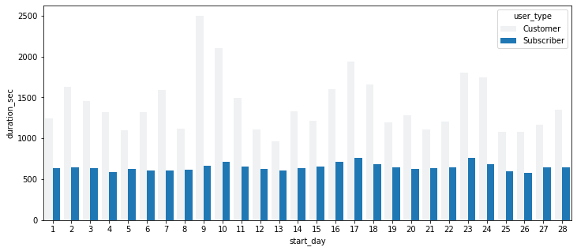

```python
# plot start day,user_type and duration
plt.figure(figsize=(12,5))
sb.barplot(x="start_day", y="duration_sec", hue="user_type",
                data=df, ci=None,saturation=1,color=default_color)
plt.figure(figsize=(12,5));
```

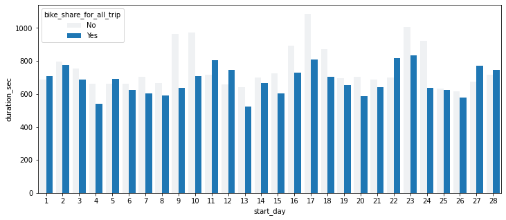

```python
# plot start day  bike_share_for_all_trip and duration
plt.figure(figsize=(12,5))
sb.barplot(x="start_day", y="duration_sec", hue="bike_share_for_all_trip",
                data=df, ci=None,saturation=1,color=default_color)
plt.figure(figsize=(12,5));
```

the bar plots above show that one instance of the categorical variables usually has an average mean dorminant over the other(s) so day is not a good variabe for predicting the duration but it can help show its distribution of trips across the entire month

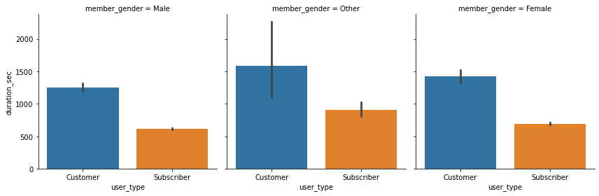

```python
# plot duration, member_gender and and user_type
g = sb.catplot(x="user_type",y='duration_sec', col="member_gender",
                data=df,height=4,
                kind="bar");
```

customers of all gender type have high mean duration than their corressponding subscribers which indicates that base on user type and gender, customers will likely have a high duration. A more detail view is to be investigated with another variable in place to get a more better judgement

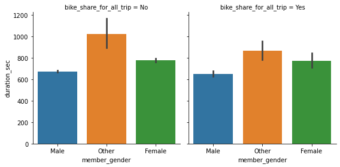

```python
# plot duration, member_gender and and bike_share_for_all_trip
g = sb.catplot(x="member_gender",y='duration_sec', col="bike_share_for_all_trip",
                data=df, height=4,
                kind="bar")
```

this shows that male who netheir use bike share for all trip have the lowest mean and Other gender the highest duration this could just be due to the fact that there are more male than any other gender in the dataset

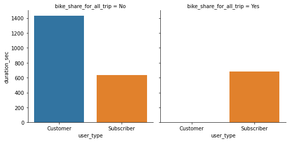

```python
# plot duration, bike_share_for_all-trip and and user_type
g = sb.catplot(x="user_type",y='duration_sec', col="bike_share_for_all_trip",
                data=df,height=4,
                kind="bar", ci=None)
```

customers who don't use bike share for all trip have a high mean duration than subscribers of the same category. On the other hand it qite clear that subscribers who use bike share for all trip always have have a high duration mean than customers who do so. This is an indication that user type has a strong influence on the duration

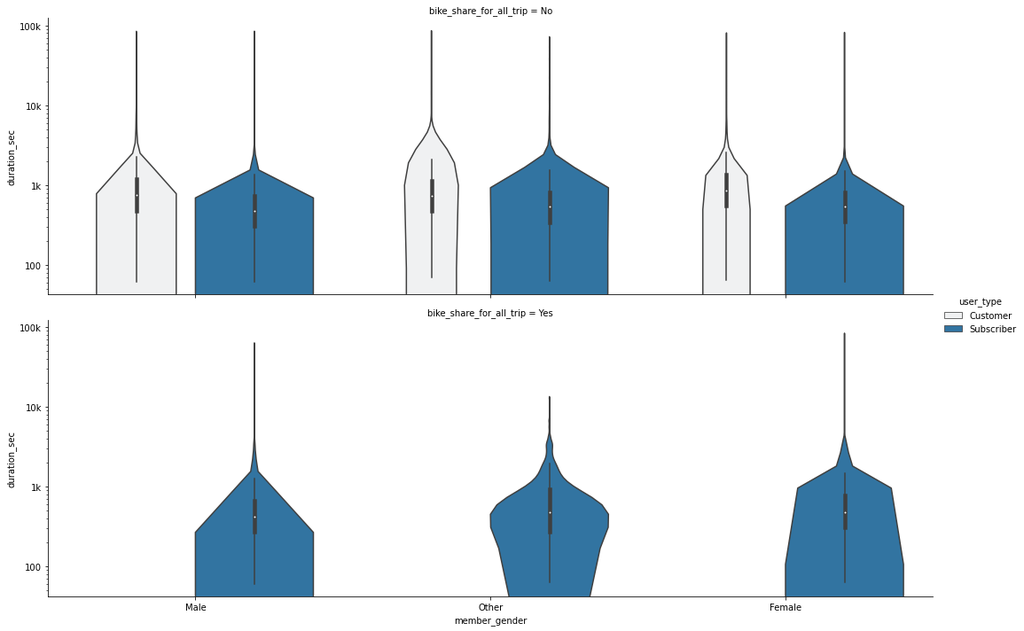

```python
# violin plot of duration, member_gender, user_type and bike_share_for_all_trip
g = sb.catplot(x="member_gender", y="duration_sec",
                hue="user_type", row="bike_share_for_all_trip",
                data=df,
                  aspect=3, color=default_color,
                kind="violin", dodge=True)
plt.yscale('log')
plt.yticks([1e2,1e3,1e4,1e5],[100,'1k','10k','100k']);
```

```python
# create a dataframe for  male gender
df_male=df[df.member_gender=='Male']
```

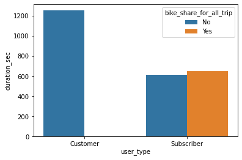

```python
# bar plot of user_type,  duration  and bike share for all trip for males
sb.barplot(data = df_male, x = 'user_type', y = 'duration_sec', hue = 'bike_share_for_all_trip',
              ci=None)
```

it is clear that male customers who don't take bike share for all trip are likely to have high duration while those males who take bike share for all trip are likely to have very low duration or no trip at all. On the other hand male subscribers who take bikeshare for all trips tend to have slightly higher durations thand those who don't

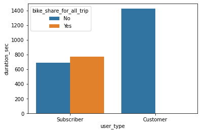

```python
# bar plot of user_type,  duration  and bike share for all trip for female gender
sb.barplot(data = df[df.member_gender=='Female'], x = 'user_type', y = 'duration_sec', hue = 'bike_share_for_all_trip',  ci=None, dodge = 0.4)
```

explanation goes same as with males

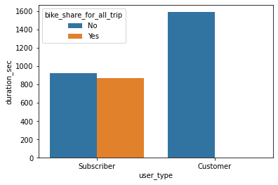

```python
# bar plot of user_type,  duration  and bike share for all trip for Other gender
sb.barplot(data = df[df.member_gender=='Other'], x = 'user_type', y = 'duration_sec', hue = 'bike_share_for_all_trip',  ci=None, dodge = 0.4);
```

Here depictition is same as for other genders except for the fact that subscribers who don't take bike share for all trip have high durations than than those who do

### Talk about some of the relationships you observed in this part of the investigation. Were there features that strengthened each other in terms of looking at your feature(s) of interest?

In this section I went futher to investigate gender, user type and bike_share_for_all-trip all collectively influence duration. These plots showed a clear distinction in duration of for all the different categories of this variables

### Were there any interesting or surprising interactions between features?

bar plot of user_type, duration and bike share for all trip for Other gender showed that subscribers who don't take bike_share for all trip had high mean duration than those who take bike share for all trips